# Gestión del presupuesto semanal de los estudiantes UTEC del ciclo 2023-1

Análisis de gasto, ahorro y presupuesto semanal

31 Agosto, 2023

# 1 Introduccion

*Comentario: Se requiere adjuntar el excel en la misma carpeta donde se abrirá el Rmd para que se pueda visualizar el Html correctamente.*

## 1.1 Objetivos:

> Objetivo general: Evaluar el conocimiento y la aplicación de la gestión financiera en los estudiantes matriculados en la UTEC durante el ciclo 2023-1.

Como *objetivos específicos* del presente proyecto, se tienen los siguientes: - Determinar si los estudiantes matriculados en la UTEC durante el ciclo 2023-1 tienen conocimientos sobre Gestión financiera

- Analizar si ponen en práctica los conocimientos sobre gestión financiera, en base a la cantidad promedio de gastos semanales.
- Analizar el presupuesto semanal de los estudiantes de la UTEC según su escala de pago asignada y sus gastos realizados semanales.

## 1.2 Relevancia

La gestión del presupuesto personal es fundamental para la estabilidad financiera y decisiones acertadas sobre gastos y ahorros de los estudiantes de la UTEC. Evaluar la gestión de su presupuesto semanal permitirá identificar áreas de mejora y brindarles herramientas para desarrollar hábitos financieros, que serán útiles en su carrera y vida profesional. En la UTEC, es común que los estudiantes realicen proyectos grupales con presupuestos limitados, esto simula situaciones reales que enfrentarán en su vida laboral. Una formación económica temprana, evita dificultades para gestionar recursos asignados en proyectos más grandes. Una buena gestión del presupuesto personal implica equilibrar ingresos, gastos, establecer prioridades y ahorrar. Estas habilidades son transferibles a proyectos grupales, donde decisiones financieras acertadas marcan la diferencia. En conclusión, evaluar la gestión del presupuesto semanal de los estudiantes de la UTEC es relevante con su formación y carrera. Desarrollar hábitos financieros tempranos beneficiará su bienestar económico, personal y los prepara para enfrentar proyectos grupales en ciclos superiores y vida laboral. La eficiente gestión de recursos es clave para el éxito.

## 1.3 Planificacion

Para manejar la distribución de nuestro proyecto entre todos, elaboramos un Diagrama de Gantt

```r
#install.packages('psych')
#install.packages('dplyr')
#install.packages('readr')
#install.packages('DescTools')
#install.packages('car')
#install.packages('tidyr')
#install.packages('ggplot2')
#install.packages('tidyverse')
# install.packages('ISLR')
```

```r
library(fastGraph)
library(rriskDistributions)
library(psych)
library(dplyr)
library(readr)
library(DescTools)
library(car)
library(tidyr)
library(ggplot2)
```

Planificación

```r
datos <- data.frame(nombre = c("Leydy", "Milagros", "Christofer", "Noe", "Todos", "Todos","Leydy","Milagros","Christofer", "Noe","Milagros", "Leydy", "Christofer", "Georgina", "Todos", "Leydy", "Noe", "Todos","Milagros","Christofer","Todos","Leydy","Noe","Todos","Milagros","Georgina","Christofer"),
                     inicio = c("Dia 01", "Dia 01", "Dia 02", "Dia 02", "Dia 02","Dia 02","Dia 02","Dia 03","Dia 03","Dia 03","Dia 04","Dia 04","Dia 04","Dia 04","Dia 04", "Dia 05", "Dia 05","Dia 06","Dia 06", "Dia 06","Dia 07","Dia 07","Dia 07","Dia 08","Dia 08","Dia 09","Dia 09"),
                     fin = c("Dia 02", "Dia 02" , "Dia 03", "Dia 03", "Dia 03","Dia 03","Dia 03", "Dia 04","Dia 04","Dia 04", "Dia 05", "Dia 05", "Dia 05", "Dia 05", "Dia 05", "Dia 06", "Dia 06", "Dia 07", "Dia 07", "Dia 07","Dia 08","Dia 08","Dia 08","Dia 09","Dia 09","Dia 10","Dia 10"),
                     Tareas = c("Elaboracion de la encuesta", "Elaboracion de la encuesta", "Recolección de datos","Recolección de datos","Elaboración del informe","Elaboración del informe", "Elaboración del informe", "Limpieza de datos", "Limpieza de datos", "Limpieza de datos","Elaboración del informe" , "Elaboración del informe","Elaboracion del informe","Analisis descriptivo ", "Analisis descriptivo ","Presentar PG1", "Presentar PG1", "Redaccion del informe final","Redaccion del informe final","Redaccion del informe final","Probabilidades","Distribucion","Distribucion","Hacer los Objetivos","Hacer los Objetivos","Presentar el PG2","Presentar el PG2"))

datos$Tareas = factor(datos$Tareas)

levels(datos$Tareas)
```

```
##  [1] "Analisis descriptivo "       "Distribucion"
##  [3] "Elaboracion de la encuesta"  "Elaboracion del informe"
##  [5] "Elaboración del informe"     "Hacer los Objetivos"
##  [7] "Limpieza de datos"           "Presentar el PG2"
##  [9] "Presentar PG1"               "Probabilidades"
## [11] "Recolección de datos"        "Redaccion del informe final"
```

```r
datos$Tareas <- factor (datos$Tareas, levels = c("Hacer los Objetivos","Elaboracion de la encuesta","Recolección de datos","Elaboración del informe","Limpieza de datos","Analisis descriptivo","Presentar PG1","Redaccion del informe final PG1","Probabilidades","Distribucion","Presentar el PG2","Revision del informe"))
levels(datos$Tareas)
```

```
##  [1] "Hacer los Objetivos"             "Elaboracion de la encuesta"
##  [3] "Recolección de datos"            "Elaboración del informe"
##  [5] "Limpieza de datos"               "Analisis descriptivo"
##  [7] "Presentar PG1"                   "Redaccion del informe final PG1"
##  [9] "Probabilidades"                  "Distribucion"
## [11] "Presentar el PG2"                "Revision del informe"
```

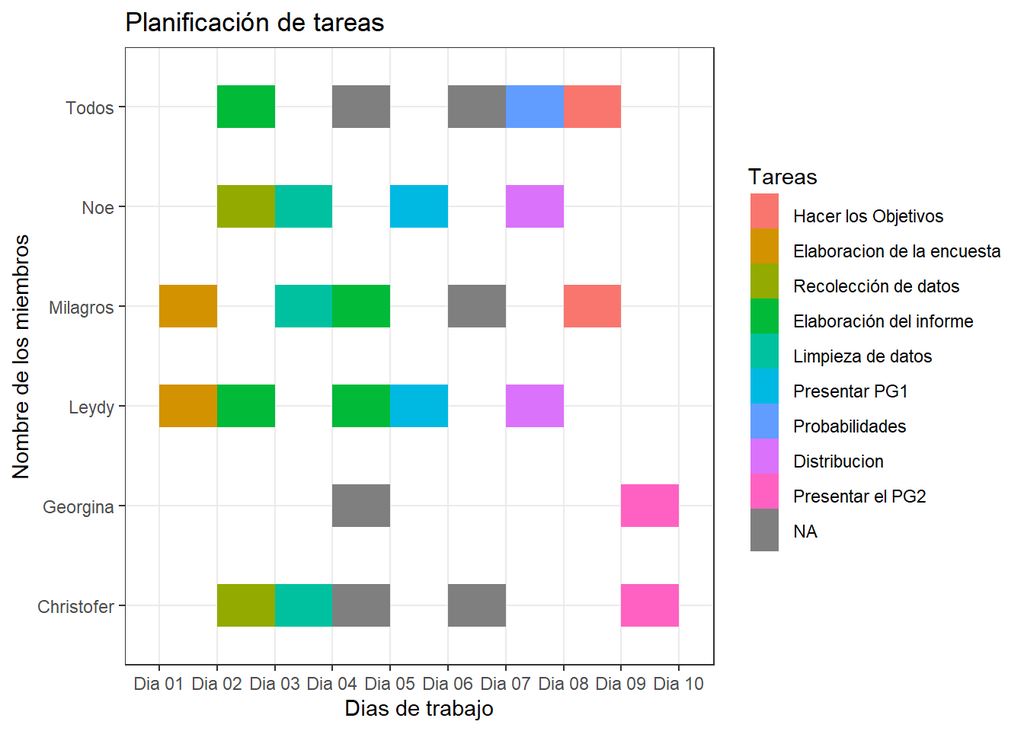

```r
ggplot(datos, aes(x=inicio, xend=fin, y=nombre, yend=nombre, color=Tareas)) +
  theme_bw()+
   geom_segment(size=10) +
   labs(x = 'Dias de trabajo', y = 'Nombre de los miembros',title = "Planificación de tareas",)
```

# Datos

## 1.4 Proceso de recolección de datos

Elegimos trabajar con los datos recopilados por una encuesta debido a que el análisis de este tema es importante con respecto a la realidad de los estudiantes de la presente universidad mediante descriptores gráficos como la comparación del grado de dependencia económica entre los estudiantes que estudian y los que estudian y trabajan, por ejemplo. Una vez que se aceptó el tema de forma unánime, se procedió a determinar las variables, y luego a elaborar las preguntas que nos permitirán recoger las respuestas a dichas variables. Finalmente, se optó por revisar en grupo las restricciones a las variables, puesto que en algunas preguntas, no estaban muy definidas. Dicho aspecto se mejoró y la encuesta quedó terminada, a la espera de que el asistente la apruebe.

## 1.5 Enlace a encuesta

Para acceder a la encuesta, acceda al siguiente enlace [Encuesta](https://docs.google.com/forms/d/e/1FAIpQLSeitnsLrSGw2S-478NG1Lmlbsfi4r9biMMMKFnfgNkvhMqmfg/viewform)

## 1.6 Población, muestra y muestreo

Ejemplo: La población de estudio es la comunidad de UTEC y la unidad muestral serán los estudiantes matriculados en el 2023-01. El tamaño de la muestra se proyecta hacia 200 observaciones, aproximadamente. El tipo de muestreo es aleatorio simple (MAS) ,ya que nuestra muestra será escogida al azar. Del mismo modo, la representatividad consta de estudiantes de diferentes ciclos de UTEC, además de los estudiantes que también trabajan, lo que nos permitirá realizar un análisis más representativo.

**Gráficas necesarias para la PG2**

### 1.6.1 ORGANIZACION: (OK)

```r
BD2 <- read_csv('GyP semanalLimpio.csv')
BD <- read_csv('GyP semanalLimpio.csv')
```

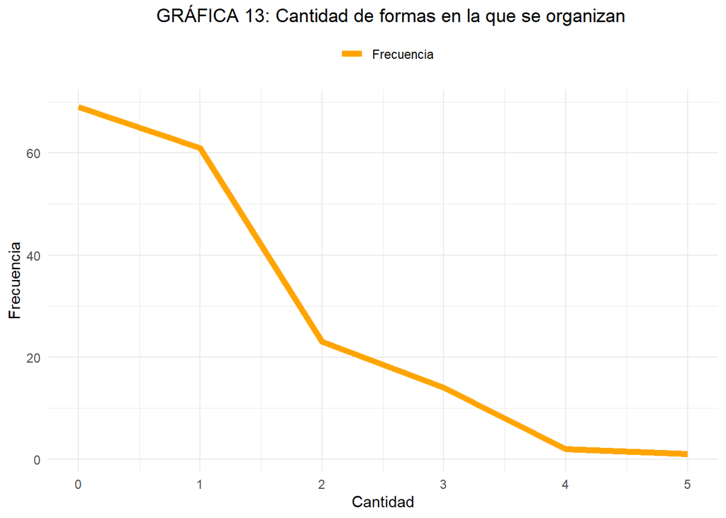

```r
tabla_frec <- table(BD2$Organizacion)
df_frec <- data.frame(Organizacion = as.numeric(names(tabla_frec)), Frecuencia = as.vector(tabla_frec))
df_frec <- df_frec[order(df_frec$Organizacion), ]
ggplot(df_frec, aes(x = Organizacion, y = Frecuencia, color = "Frecuencia")) + geom_line(size = 2) + labs(x = "Cantidad", y = "Frecuencia", title ="                    GRÁFICA 13: Cantidad de formas en la que se organizan") + scale_color_manual(values = "orange", name = NULL) + theme_minimal() + theme(legend.position = "top")
```

### 1.6.2 Satisfacción de presupuesto por el nivel de administración: (OK)

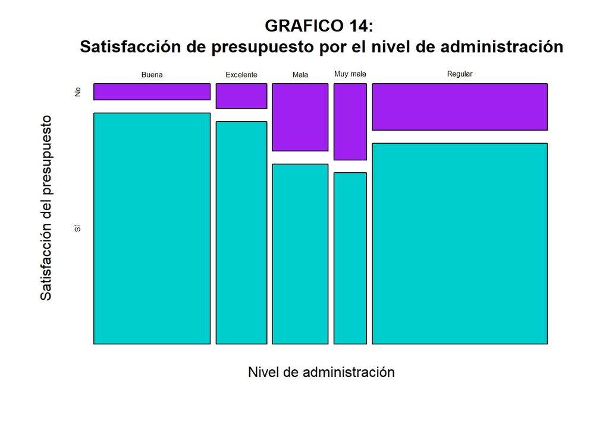

```r
mosaicplot(table(BD$NiveldeAdministraicon ,BD$SatisfaccionPresupuestoS ),
           col=c("purple","cyan3"),
           main="GRAFICO 14:
Satisfacción de presupuesto por el nivel de administración",cex.axis = 0.54, xlab="Nivel de administración",ylab="Satisfacción del presupuesto",off=5)
```

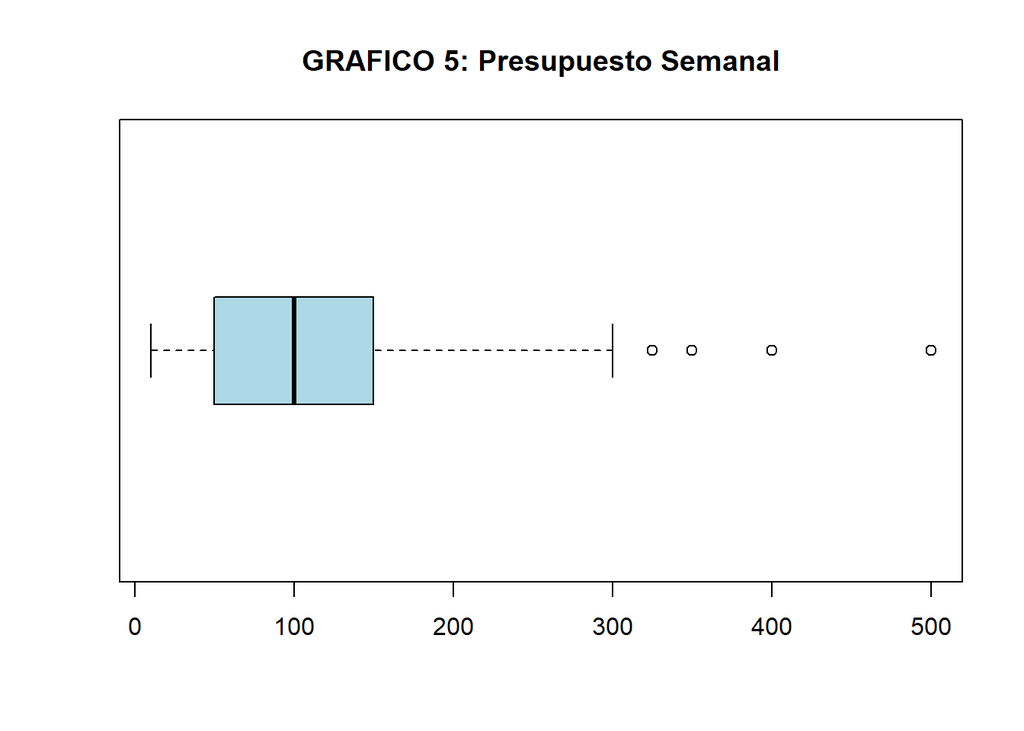

```r
boxplot(BD2$PresupuestoS,
        main = "GRAFICO 5: Presupuesto Semanal",horizontal = TRUE,
        boxwex = 0.5,col="lightblue")
```

## 1.7 1. Grafica de ahorro semanal:

En promedio la cantidad de ahorro semanal de los estudiantes es de 15 soles. También, observamos la existencia de datos atípicos, esto se debe a que algunos estudiantes trabajan y tienen más ingresos para ahorrar.

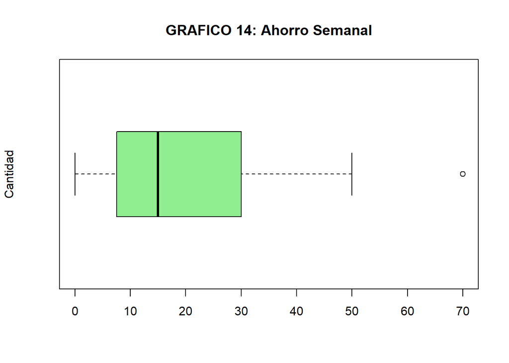

### 1.7.1 Gasto semanal en transporte: (OK)

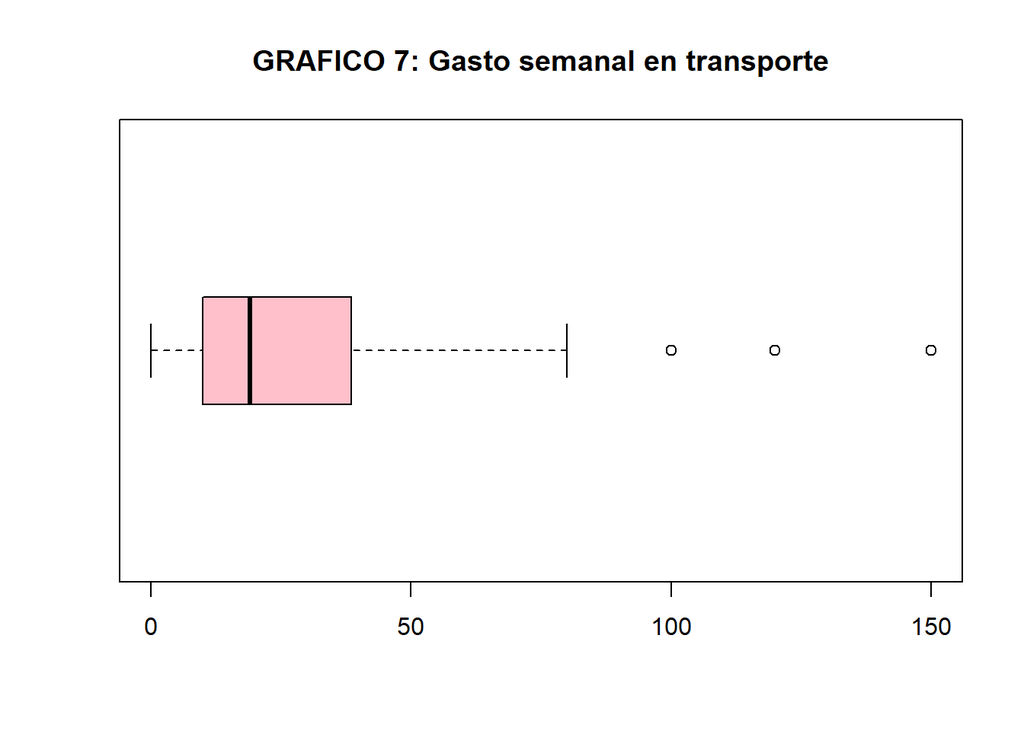

```r
boxplot(BD2$GastoSemanalTransporte ,
        main = "GRAFICO 7: Gasto semanal en transporte",horizontal = TRUE,
        boxwex = 0.5,col="pink")
```

# 2 ANÁLISIS PROBABILÍSTICOS

## 2.1 **Probabilidad empírica**

Para la probabilidad empírica elijo 2 variables interesantes que son la variable Ahorro Semanal y Presupuesto Semanal, para ello para ambas variables las coloco en intervalos.

```r
unique(BD2$AhorroSemanal)
```

```
##  [1] 30.0  5.0 15.0 35.0 20.0  7.5 50.0  1.0 18.0 10.0 40.0  8.0  7.0  4.0  0.0
## [16] 70.0 25.0  2.0 14.0 12.0  6.0
```

```r
BD2 %>% mutate( AhorroSemanal=
       ifelse(AhorroSemanal %in% c(0.0,1.0,2.0,4.0,5.0,6.0,7.0,7.5,8.0,10.0), "0-10",
       ifelse(AhorroSemanal %in% c(12.0,14.0,15.0,18.0,20,0,25.0, 30.0),"11-30",
       ifelse(AhorroSemanal %in% c(35.0,40.0, 50.0,70.0 ), "31-70", AhorroSemanal))))-> BD2

BD2 %>% count(AhorroSemanal) %>% arrange(match(AhorroSemanal, c("0-10", "11-30", "31-70")))
```

```
## # A tibble: 3 x 2
##   AhorroSemanal     n
##   <chr>         <int>
## 1 0-10             73
## 2 11-30            63
## 3 31-70            34
```

**Espacio muestral**

$\Omega = \{ AhorroS\ entre\ 0 \ y \ 10 \ soles \ , \ AhorroS \ entre \ 11 \ y \ 30 \ soles \ , \ AhorroS \ entre \ 31 \ y \ 70 \ soles \}$

**Definiendo los eventos atómicos**

Evento A: Elegir a un estudiante que ahorre entre 0 y 10 soles semanalmente en una muestra de tamaño 170

Evento B: Elegir a un estudiante que ahorre entre 11 y 30 soles semanalmente en una muestra de tamaño 170

Evento C: Elegir a un estudiante que ahorre entre 31 y 70 soles semanalmente en una muestra de tamaño 170

**calculando la probabilidad para cada evento**

$P(X) = \frac{Casos \ favorables}{Casos \ totales}$

- Para el primer evento

Determinar la probabilidad de seleccionar un estudiante que ahorre semanalmente entre 0 y 10 soles en una muestra de tamaño 170?

$P(A) = \frac{73}{170} = 0.4294118$

```r
# Probabilidad del Ahorro semanal entre el valor de  0 y 10 soles
(73/170)
```

```
## [1] 0.4294118
```

- Para el 2do evento

Determinar la probabilidad de seleccionar un estudiante que ahorre semanalmente entre 11 y 30 soles en una muestra de tamaño 170?

$P(B) = \frac{63}{170} = 0.3705882$

```r
# Probabilidad del Ahorro semanal entre el valor de 11 y 30 soles
(63/170)
```

```
## [1] 0.3705882
```

- Para el tercer evento

Determinar la probabilidad de seleccionar un estudiante que ahorre semanalmente entre 31 y 70 soles en una muestra de tamaño 170?

$P(C) = \frac{34}{170} = 0.2$

```r
# Probabilidad del presupuesto semanal entre el valor de 31 y 70 soles
(34/170)
```

```
## [1] 0.2
```

##2da variable

```r
unique(BD2$PresupuestoS)
```

```
##  [1] 100.00 150.00  50.00  80.00  10.00 200.00  20.00 110.00  40.00  70.00
## [11] 250.00 130.00  60.00 120.00 180.00  25.00 300.00 400.00 105.89  87.00
## [21]  73.00  30.00  55.00 240.00  14.40  15.00 140.00 160.00  72.00 125.00
## [31] 500.00 325.00  75.00 350.00  35.00 153.00
```

```r
BD2 %>% mutate( PresupuestoS=
       ifelse(PresupuestoS %in% c(10.00,14.40,15.00,20.00,25.00,30.00,35.00,40.00,50.00,55.00,60.00,70.00,72.00,73.00,75.00,80.00,87.00,100.00),"10-100",
       ifelse(PresupuestoS %in% c(105.89,110.00,120.00,125.00,130.00,140.00,150.00,153.00,160.00,180.00,200.00,240.00,250.00,300.00), "101-300",
       ifelse(PresupuestoS %in% c(300.00,325.00,350.00,400.00,500.00), "301-500", PresupuestoS
))))-> BD2
BD2 %>% count(PresupuestoS) %>% arrange(match(PresupuestoS, c("10-100", "101-300", "301-500")))
```

```
## # A tibble: 3 x 2
##   PresupuestoS     n
##   <chr>        <int>
## 1 10-100         101
## 2 101-300         62
## 3 301-500          7
```

**Espacio muestral**

$\Omega = \{ PresupuestoS\ entre\ 10 \ y \ 100 \ soles \ , \ PresupuestoS \ entre \ 101 \ y \ 300 \ soles \ , \ PresupuestoS\ entre \ 301 \ y \ 500 \ soles \}$

**Definiendo los eventos atómicos**

**calculando la probabilidad para cada evento**

$P(X) = \frac{Casos \ favorables}{Casos \ totales}$

- Para el primer evento

Determinar la probabilidad de seleccionar un estudiante que tenga un presupuesto semanal entre 10 y 100 soles en una muestra de tamaño 170?

$P(D) = \frac{101}{170} = 0.5941176$

```r
# Probabilidad del presupuesto semanal entre el valor de  10 y 100 soles
(101/170)
```

```
## [1] 0.5941176
```

- Para el 2do evento

Determinar la probabilidad de seleccionar un estudiante que tenga un presupuesto semanal entre 101 y 300 soles en una muestra de tamaño 170?

$P(E) = \frac{62}{170} = 0.3647059$

```r
# Probabilidad del presupuesto semanal entre el valor de 101 y 300 soles
(62/170)
```

```
## [1] 0.3647059
```

- Para el tercer evento

$P(F) = \frac{7}{170} = 0.04117647$

```r
# Probabilidad del presupuesto semanal entre el valor de 301 y 500 soles
(7/170)
```

```
## [1] 0.04117647
```

#Probabilidad condicional

```r
unique(BD2$AhorroSemanal)
```

```
## [1] "11-30" "0-10"  "31-70"
```

```r
BD %>% mutate( AhorroSemanal=
       ifelse(AhorroSemanal %in% c(0.0,1.0,2.0,4.0,5.0,6.0,7.0,7.5,8.0,10.0), "0-10",
       ifelse(AhorroSemanal %in% c(12.0,14.0,15.0,18.0,20,0,25.0, 30.0),"11-30",
       ifelse(AhorroSemanal %in% c(35.0,40.0, 50.0,70.0 ), "31-70", AhorroSemanal))))-> BD

BD %>% count(AhorroSemanal) %>% arrange(match(AhorroSemanal, c("0-10", "11-30", "31-70")))
```

```
## # A tibble: 3 x 2
##   AhorroSemanal     n
##   <chr>         <int>
## 1 0-10             73
## 2 11-30            63
## 3 31-70            34
```

```r
unique(BD2$PresupuestoS)
```

```
## [1] "10-100"  "101-300" "301-500"
```

```r
BD %>% mutate( PresupuestoS=
       ifelse(PresupuestoS %in% c(10.00,14.40,15.00,20.00,25.00,30.00,35.00,40.00,50.00,55.00,60.00,70.00,72.00,73.00,75.00,80.00,87.00,100.00),"10-100",
       ifelse(PresupuestoS %in% c(105.89,110.00,120.00,125.00,130.00,140.00,150.00,153.00,160.00,180.00,200.00,240.00,250.00,300.00), "101-300",
       ifelse(PresupuestoS %in% c(300.00,325.00,350.00,400.00,500.00), "301-500", PresupuestoS
))))-> BD
BD %>% count(PresupuestoS) %>% arrange(match(PresupuestoS, c("10-100", "101-300", "301-500")))
```

```
## # A tibble: 3 x 2
##   PresupuestoS     n
##   <chr>        <int>
## 1 10-100         101
## 2 101-300         62
## 3 301-500          7
```

### 2.1.1 Par de evento dependientes

Seleccionamos: Dias asistidos a la U y presupuesto semanal

Definimos el evento:  
A: “Seleccionar una asistencia de 6 dias por semana a la universidad”

```r
 probAsistencia <- table(BD$AsistenciaUniversidad)
 probAsistencia
```

```
##
##  2  3  4  5  6
##  3  6 20 74 67
```

B: “Seleccionar presupuesto semanal que sea mayor a 100 soles y menor o igual 300 soles”

```r
 probPresupuestoS <- table(BD$PresupuestoS)
 probPresupuestoS
```

```
##
##  10-100 101-300 301-500
##     101      62       7
```

Espacio muestral: {Asitencia de 6 dias}  
Espacio muestral: {Presupuesto semanal mayor a 100 y menor igual a 300 soles }

- Hallamos la probabilidad de cada evento independiente:
- Probabilidad por dato en la variable asistencia

```r
   Pasistencia <- probAsistencia/sum(probAsistencia)
 P_1 <- data.frame(Evento = c(2,3,4,5,6), Probabilidad1= c(Pasistencia))
 P_1
```

```
##   Evento Probabilidad1
## 2      2    0.01764706
## 3      3    0.03529412
## 4      4    0.11764706
## 5      5    0.43529412
## 6      6    0.39411765
```

- Probabilidad por dato en la variable presupuesto semanal

```r
   PpresupuestoS <- probPresupuestoS/sum(probPresupuestoS)
 P_2 <- data.frame(Evento = c("10-100","101-300","301-500"), Probabilidad= c(PpresupuestoS ))
 P_2
```

```
##          Evento Probabilidad
## 10-100   10-100   0.59411765
## 101-300 101-300   0.36470588
## 301-500 301-500   0.04117647
```

```r
Asistencia <- c(Pasistencia)
Presupuesto <- c(PpresupuestoS)
# Crear una matriz multiplicando los valores de los vectores
matrizAxP <- outer(Presupuesto, Asistencia, "*")

# Convertir la matriz en un data frame
dataframeAxP <- as.data.frame(matrizAxP)

# Asignar los nombres de las filas y columnas
rownames(dataframeAxP) <- names(Presupuesto)
colnames(dataframeAxP) <- names(Asistencia)

# Imprimir el data frame resultante
dataframeAxP
```

```
##                    2           3           4          5          6
## 10-100  0.0104844291 0.020968858 0.069896194 0.25861592 0.23415225
## 101-300 0.0064359862 0.012871972 0.042906574 0.15875433 0.14373702
## 301-500 0.0007266436 0.001453287 0.004844291 0.01792388 0.01622837
```

Aqui calculamos la probabilidad para cada caso existente dado los dos espacios muestrales de cada variable

Ahora calcularemos la probabilidad de una asistencia de 6 dias y un presupuesto mayor a 100 soles y menor igual a 300, la probabilidad de que ocurran ambos eventos a la vez y calcularemos la multiplicación de ambas probabilidades

```r
# Probabilidades marginales
P_Masistencia <- sum(dataframeAxP[1:3,5])
P_Mpresupuesto <- sum(dataframeAxP[2,1:5])

# Probabilidad conjunta
P_MayMp <- (nrow(filter(BD,PresupuestoS == "101-300" & AsistenciaUniversidad==6)))/170

# Imprimir resultado
P_MayMp
```

```
## [1] 0.1588235
```

```r
P_Masistencia*P_Mpresupuesto
```

```
## [1] 0.143737
```

Igualamos el valor obtenido de la intersección con la multiplicación de las probabilidades marginales de Asistencia y presupuesto, al guiarnos de la formula de P(Ainterceptado B) = P(A)P(B) las cuales al cumplirse la igualdad seria independientes pero al ser diferentes en este caso podríamos decir que son dependientes.

### 2.1.2 Par de eventos dependientes

Seleccionamos: Ahorro semanal y presupuesto semanal Definimos el evento: Ahorros: “Seleccionamos ahorros mayores a 30 soles”

```r
 probAhorro <- table(BD$AhorroSemanal)
 probAhorro
```

```
##
##  0-10 11-30 31-70
##    73    63    34
```

Presupuesto: “Seleccionar presupuesto semanal que sea mayor a 100 soles y menor o igual 300 soles”

```r
 probPresupuestoS <- table(BD$PresupuestoS)
 probPresupuestoS
```

```
##
##  10-100 101-300 301-500
##     101      62       7
```

Espacio muestral: {Ahorro mayor a 30 soles} Espacio muestral: {Presupuesto semanal mayor a 100 y menor igual a 300 soles} - Hallamos la probabilidad de cada evento independiente: *Probabilidad por dato en la variable ahorro semanal

```r
    PahorroS <- probAhorro/sum(probAhorro)
P_3 <- data.frame(Evento = c("0-10","11-30","31-70"), Probabilidad= c(PahorroS ))
P_3
```

```
##       Evento Probabilidad
## 0-10    0-10    0.4294118
## 11-30  11-30    0.3705882
## 31-70  31-70    0.2000000
```

- Probabilidad por dato en la variable presupuesto semanal

```r
   PpresupuestoSe <- probPresupuestoS/sum(probPresupuestoS)
 P_4 <- data.frame(Evento = c("10-100","101-300","301-500"), Probabilidad= c(PpresupuestoSe ))
 P_4
```

```
##          Evento Probabilidad
## 10-100   10-100   0.59411765
## 101-300 101-300   0.36470588
## 301-500 301-500   0.04117647
```

```r
Ahorro <- c(PahorroS)
PresupuestoS <- c(PpresupuestoSe)
# Crear una matriz multiplicando los valores de los vectores
matrizAhxP <- outer(PresupuestoS, Ahorro, "*")

# Convertir la matriz en un data frame
dataframeAhxP <- as.data.frame(matrizAhxP)

# Asignar los nombres de las filas y columnas
rownames(dataframeAhxP) <- names(PresupuestoS)
colnames(dataframeAhxP) <- names(Ahorro)

# Imprimir el data frame resultante
dataframeAhxP
```

```
##               0-10      11-30       31-70
## 10-100  0.25512111 0.22017301 0.118823529
## 101-300 0.15660900 0.13515571 0.072941176
## 301-500 0.01768166 0.01525952 0.008235294
```

Aqui calculamos la probabilidad para cada caso existente dado los dos espacios muestrales de cada variable

Ahora calcularemos la probabilidad de un ahorro mayoe a 30 soles y un presupuesto mayor a 100 soles y menor igual a 300, la probabilidad de que ocurran ambos eventos a la vez y calcularemos la multiplicación de ambas probabilidades

```r
# Probabilidades marginales
P_Mahorro <- sum(dataframeAhxP[1:3,3])
P_Mpresupuesto1 <- sum(dataframeAhxP[2,1:3])

# Probabilidad conjunta
P_MahyMp1 <-  (nrow(filter(BD, PresupuestoS == "101-300" & AhorroSemanal == "31-70")))/170

# Imprimir resultado
P_MahyMp1
```

```
## [1] 0.1117647
```

```r
P_Mahorro * P_Mpresupuesto1
```

```
## [1] 0.07294118
```

```r
#install.packages("rriskDistributions")
```

```r
library(rriskDistributions)
```

# 3 Variables discreta

## 3.1 1ERA VARIABLE

Para el análisis de variables discretas usaremos la variable Organización

```r
fi = table(BD2$Organizacion)
pi=round(prop.table(fi)*100,2)
cbind(fi,pi)
```

```
##   fi    pi
## 0 69 40.59
## 1 61 35.88
## 2 23 13.53
## 3 14  8.24
## 4  2  1.18
## 5  1  0.59
```

**Función de probabilidad**

```r
fi = table(BD2$Organizacion)
pi=round(prop.table(fi),4)
pi
```

```
##
##      0      1      2      3      4      5
## 0.4059 0.3588 0.1353 0.0824 0.0118 0.0059
```

Con hist verifico a que variable se asemeja mi variable Organización para así poder saber que distribución usar

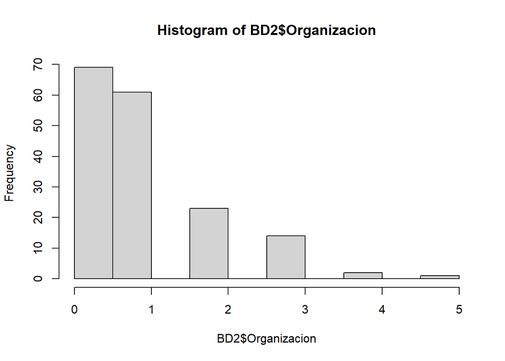

```r
hist(BD2$Organizacion)
```

Según la gráfica que obtuve, podría decir que mi variable organización sería una distribución geométrica

**Realizamos el éxito y el fracaso**

Éxito: Estudiantes de la UTEC que se organizan de 1 forma

Fracaso : Estudiantes de la UTEC que se organicen más de 1 forma

**Probabilidad de éxito y fracaso**

```r
61/170
```

```
## [1] 0.3588235
```

```r
1-0.36
```

```
## [1] 0.64
```

**Variable aleatoria**

X : N° de intentos necesarios para encontrar el primer estudiante de la UTEC que se organice de una sola forma

Rx = {0,1,2,3,4,5}

**Identifico parámetros**

X ~G(p)

entonces: X~G(0.36)

**Gráficamos**

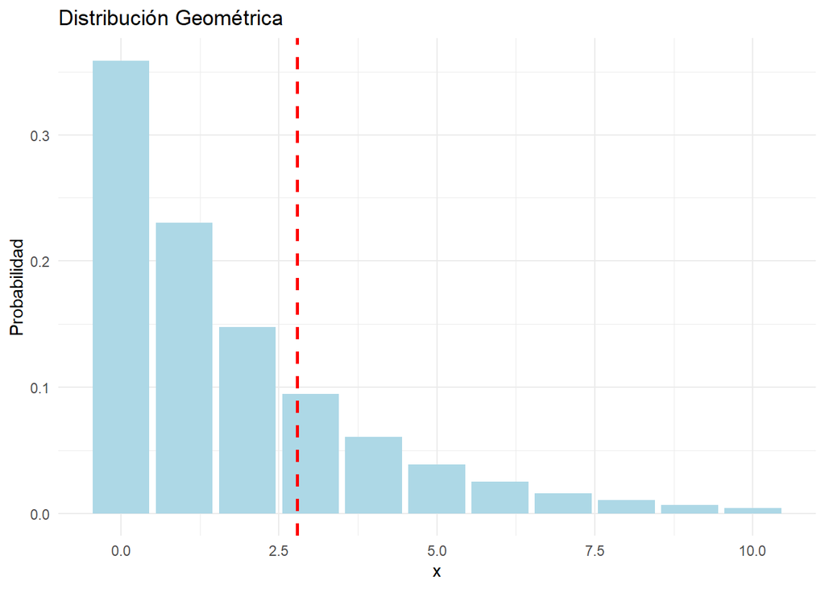

```r
# Definir parámetro de la distribución geométrica
p <- 0.3588235
 # Probabilidad de éxito

# Generar valores de x para la distribución geométrica
x <- 0:10

# Calcular los valores de probabilidad para cada x
prob <- dgeom(x, prob = p)

# Crear un data frame con los valores de x y prob
data <- data.frame(x, prob)

# Graficar la distribución geométrica y la línea de esperanza
ggplot(data, aes(x)) +
  geom_bar(aes(y = prob), stat = "identity", fill = "lightblue") +
  geom_vline(xintercept = 1 / p, color = "red", linetype = "dashed", size = 1) +
  labs(title = "Distribución Geométrica",
       x = "x",
       y = "Probabilidad") +
  theme_minimal()
```

**Calculamos la esperanza**

con la ayuda de la esperanza determinaremos el valor promedio de intentos para para encontrar el primer estudiante de la UTEC que se organice de una sola forma

calculamos la esperanza

E(x) =

```r
1/0.36
```

```
## [1] 2.777778
```

Este resultado nos indica que aproximadamente en 2.78 intentos se encontrará a un estudiante que tenga una sola forma de organizarse.

**cálculos de probabilidades**

¿Cual es la probabilidad de hallar al primer estudiante que tenga una sola forma de organizar al quinto intento?

P(x=5) = dgeom(5-1,p)

```r
dgeom(4,0.36)
```

```
## [1] 0.06039798
```

¿Cual es la probabilidad de que un estudiante tenga 5 formas de organizarse después de 6 intento?

Primero calculo el éxito :

```r
1/170
```

```
## [1] 0.005882353
```

P(X>6) =

```r
pgeom(6,0.006, lower.tail = F)
```

```
## [1] 0.9587485
```

¿Cual es la probabilidad de que un estudiante tenga 3 formas de organizarse después de 6 intento?

Primero calculo el éxito :

```r
14/170
```

```
## [1] 0.08235294
```

```r
pgeom(6,0.08, lower.tail = F)
```

```
## [1] 0.5578466
```

## 3.2 2DA VARIABLE

Variable a usar es la de GastoCubierto

```r
fi = table(BD2$GastoCubierto)
pi=prop.table(fi)*100
cbind(fi,pi)
```

```
##   fi        pi
## 0 37 21.764706
## 1 20 11.764706
## 2 40 23.529412
## 3 35 20.588235
## 4 23 13.529412
## 5 15  8.823529
```

**Distribución a usar en la distribución Binomial**

**Calculo del éxito**

Determinar la probabilidad que un estudiante de la UTEC tenga 5 gastos cubiertos

P(E) =

```r
15 / sum(fi)
```

```
## [1] 0.08823529
```

**Construir la variable aleatoria (VA)**

X: Número de estudiantes de la UTEC que tienen 5 gastos cubiertos.

**Identifico parámetros**

X ~B(n,p)

Donde:

P(E) : Probabilidad de éxito, definido como tener exactamente 5 gastos cubiertos. n : Tamaño de la muestra

**Probabilidad de éxito, definido como tener exactamente 5 gastos cubiertos.**

Sea X ∼ B(n = 170, p = 0.08823529), calcular:

```r
pbinom(5,170,0.08823529)
```

```
## [1] 0.00201201
```

**Construir la densidad**

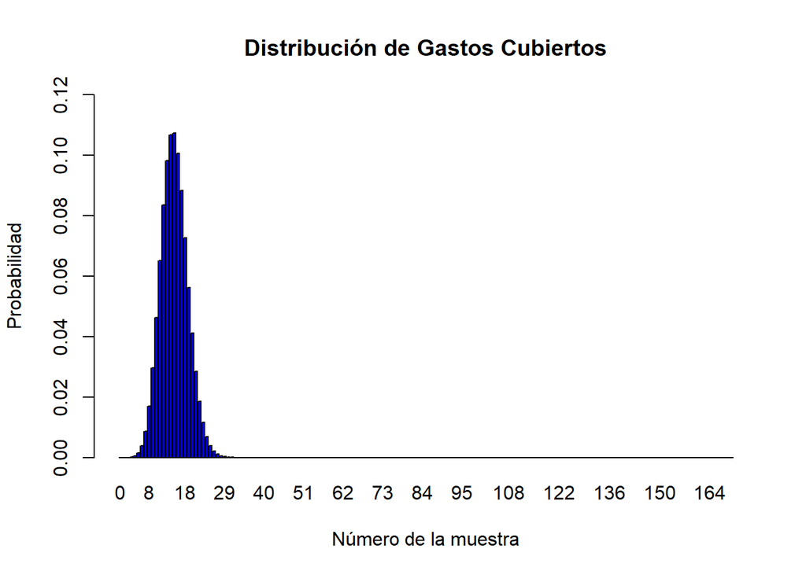

```r
# Número total de ensayos
n <- 170
# Probabilidad de éxito en cada ensayo
p <- 0.08823529
# Vector con los valores desde 0 hasta n (170)
x <- 0:n
# Calculamos las probabilidades de cada valor en x en una distribución binomial
y <- dbinom(x, n, p)
barplot(y, names.arg = x, xlab = "Número de la muestra", ylab = "Probabilidad", col = "blue", ylim = c(0, max(y) * 1.12), main = "Distribución de Gastos Cubiertos")
```

**Validar propiedades**

Varianza

```r
n*p*(1-p)
```

```
## [1] 13.67647
```

El valor de la varianza nos indica la dispersión de los datos con respecto a la media. En nuestro caso, al ser 13.67647, podemos decir que los datos tienen una dispersión moderada en relación con la media de 15.

Esperanza

```r
n*p
```

```
## [1] 15
```

El valor esperado representa el valor promedio que se espera obtener. En nuestro caso, la esperanza es igual a 15, lo que significa que se espera que 15 estudiantes tengan 5 gastos cubiertos.

Desviacion estandar

```r
sqrt(n*p*(1-p))
```

```
## [1] 3.698171
```

La desviación estándar nos proporciona una medida de dispersión de los datos alrededor de la media. En nuestro caso, la desviación estándar es de 3.698171, lo que indica que los datos tienen una dispersión moderada en relación con la media de 15.

```r
mean(BD2$GastoCubierto)
```

```
## [1] 2.188235
```

## 3.3 3ERA VARIABLE

Se quiere analizar el nivel de administración que usan los estudiantes de la UTEC, sobre todo los estudiantes que tengan un nivel Malo de administración. Este análisis será modelada mediante una distribución geométrica

```r
BD2$NuevaAdmin <- ifelse(BD2$NiveldeAdministraicon %in% c("Mala", "Muy mala"), "Mala", BD2$NiveldeAdministraicon)
```

```r
fi = table(BD2$NuevaAdmin)
pi=prop.table(fi)
cbind(fi,pi)
```

```
##           fi        pi
## Buena     46 0.2705882
## Excelente 20 0.1176471
## Mala      35 0.2058824
## Regular   69 0.4058824
```

Estudiantes que tengan un nivel de administración Mala como caso de “Éxito”

Estudiantes que tengan un nivel de administración diferente “Fracaso”

Tenemos 0.2058824 como probabilidad de éxito

**Declarando la variable aleatoria**

X: Número de ensayos hasta encontrar el primer estudiante que tenga un nivel de administración Mala

**Identifico Parámetros**

X~G(0.2058824)

¿Cuál es la probabilidad de hallar al primer estudiante que tenga un nivel de administración Mala después de 4 intentos?

P(X>4) = 1-P(X<=0.2058824) =

```r
(Prob<-1-pgeom(3,0.2058824))
```

```
## [1] 0.3976851
```

**Validando propiedades**

Valor esperado

Proporciona una medida promedio de la cantidad de ensayos requeridos para obtener el primer éxito.

E(X) =

```r
1/0.2058824
```

```
## [1] 4.857142
```

varianza

V(X) =

```r
(varianza<-(1-0.2058824)/(0.2058824)^2)
```

```
## [1] 18.73468
```

Desviación estándar

```r
(desviacion_std<-sqrt(varianza))
```

```
## [1] 4.328358
```

**Gráfica**

[figure not shown]

```r
# Definir parámetro de la distribución geométrica
p <- 0.2058824 # Probabilidad de éxito

# Generar valores de x para la distribución geométrica
x <- 0:20

# Calcular los valores de probabilidad para cada x
prob <- dgeom(x, prob = p)

# Crear un data frame con los valores de x y prob
data <- data.frame(x, prob)

# Graficar la distribución geométrica y la línea de esperanza
ggplot(data, aes(x)) +
  geom_bar(aes(y = prob), stat = "identity", fill = "lightblue") +
  geom_vline(xintercept = 1 / p, color = "red", linetype = "dashed", size = 1) +
  labs(title = "Cantidad de formas de organizarse",
       x = "x",
       y = "Probabilidad") +
  theme_minimal()
```

**Calculando probabilidades**

¿Cuál es la probabilidad de hallar al primer estudiante que tenga un nivel de administración Buena al 5to intento?

Probabilidad de éxito:

```r
46/170
```

```
## [1] 0.2705882
```

P(X=5)=

```r
dgeom(4,0.2705882)
```

```
## [1] 0.07659492
```

#VARIABLE CONTINUA

## 3.4 VARIABLES ALEATORIAS CONTINUAS 1era variable

### 3.4.1 PRECIO DE ALMUERZO

Análisis de tipo de distribución de la variable Precio de almuerzo.

```r
PMA <- BD2$PrecioMaxAlmuerzos[BD2$PrecioMaxAlmuerzos>= 15]

fit.cont(PMA)
```

```
##
## Begin fitting distributions ---------------------------------------
```

```
## * fitting normal distribution ... OK
```

```
## * fitting Cauchy  distribution ... OK
```

```
## * fitting logistic distribution ... OK
```

```
## * fitting beta distribution ... failed
```

```
## * fitting exponential distribution ... OK
```

```
## * fitting chi-square distribution ... OK
```

```
## * fitting uniform distribution ... OK
```

```
## * fitting gamma distribution ... OK
```

```
## * fitting lognormal distribution ... OK
```

```
## * fitting Weibull distribution ... OK
```

```
## * fitting F-distribution ... OK
```

```
## * fitting Student's t-distribution ... OK
```

```
## * fitting Gompertz distribution ... OK
```

```
## * fitting triangular distribution ... failed
```

```
## End fitting distributions -----------------------------------------
```

```
##                logL    AIC    BIC Chisq(value) Chisq(p) AD(value)    H(AD)
## Normal      -148.44 300.87  304.7        14.71     0.00      4.10 rejected
## Cauchy      -149.96 303.93 307.75        11.53     0.00     10.35 rejected
## Logistic    -147.97 299.93 303.76        11.29     0.00      3.65 rejected
## Exponential -196.74 395.48 397.39        44.10     0.00     14.36 rejected
## Chi-square  -148.52 299.05 300.96         8.76     0.03      3.75     NULL
## Uniform        NULL   NULL   NULL        10.14     0.01       Inf     NULL
## Gamma       -144.09 292.19 296.01        15.64     0.00      3.77 rejected
## Lognormal   -142.32 288.65 292.47        16.23     0.00      3.65 rejected
## Weibull     -150.53 305.06 308.88        11.15     0.00      3.97 rejected
## F           -262.31 528.62 532.45       255.37     0.00     26.82     NULL
## Student     -301.67 605.34 607.25       605.25     0.00     49.29     NULL
## Gompertz    -157.54 319.07  322.9        11.45     0.00      4.60     NULL
##             KS(value)    H(KS)
## Normal           0.23 rejected
## Cauchy           0.37 rejected
## Logistic         0.23 rejected
## Exponential      0.55 rejected
## Chi-square       0.26 rejected
## Uniform          0.27 rejected
## Gamma            0.22 rejected
## Lognormal        0.22 rejected
## Weibull          0.24 rejected
## F                0.70 rejected
## Student          0.83 rejected
## Gompertz         0.28 rejected
```

```
##
## Chosen continuous distribution is: NA
## Fitted parameters are:
## [1] NA
```

```r
#hist(PMA, breaks = 20, prob=T)
#lines(density(BD$PrecioMaxAlmuerzos),col="green",lwd=3)

#xs <- seq(0,30, by=0.05)
#ys <- dnorm(xs, mean =13.58765,sd=4.627998)
#hist(BD2$PrecioMaxAlmuerzos, xlim = c(8,18), breaks = 30, ylim = c(0,0.6), las = 2, ylab="",prob=T)
#lines(xs,ys, col = "yellow", lwd= 2)
```

```r
#PMA <- BD2$PrecioMaxAlmuerzos[BD2$PrecioMaxAlmuerzos>= 15 ]
mean(PMA)
```

```
## [1] 18.818
```

```r
var(PMA)
```

```
## [1] 22.64191
```

```r
sd(PMA)
```

```
## [1] 4.758352
```

```r
table(PMA)
```

```
## PMA
##   15 15.5   16 16.5   17   20 20.9   23   24   25   28   30
##   20    1    4    1    2   11    1    1    1    3    1    4
```

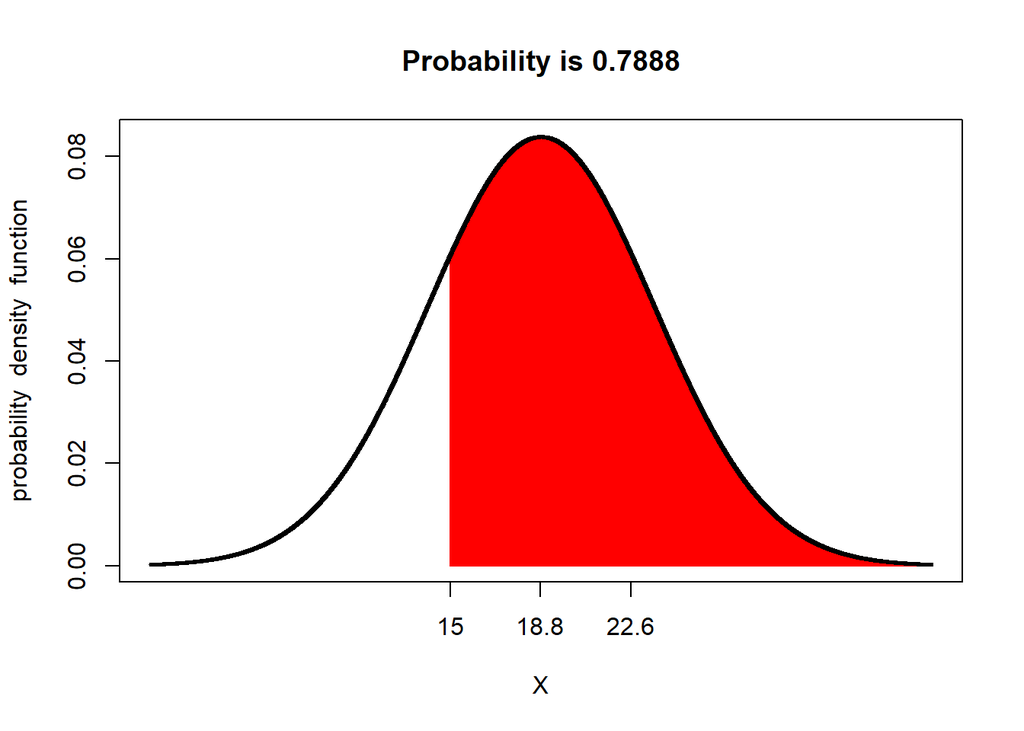

```r
shadeDist(15,"dnorm",18.818, 4.758352,F)
```

Determinar que tan probable es que un alumno de UTEC pague un monto menor o igual a 10 soles. P(X<=10)

```r
pnorm(10, 18.818, 4.758352, lower.tail = TRUE)
```

```
## [1] 0.03192953
```

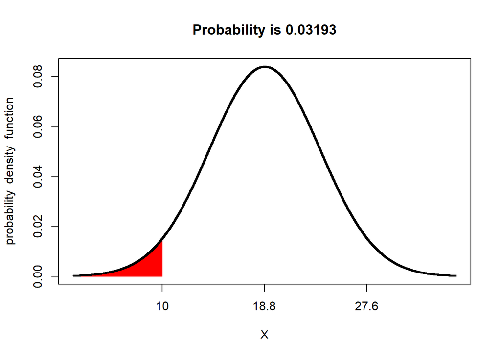

```r
shadeDist(10,"dnorm",18.818, 4.758352,T)
```

## 3.5 VARIABLES ALEATORIAS CONTINUAS 2da variable

### 3.5.1 PRECIO DE ALMUERZO

Análisis de tipo de distribución de la variable Precio de almuerzo.

```r
PMA <- BD2$PrecioMaxAlmuerzos[BD2$PrecioMaxAlmuerzos>= 15]

fit.cont(PMA)
```

```
##
## Begin fitting distributions ---------------------------------------
```

```
## * fitting normal distribution ... OK
```

```
## * fitting Cauchy  distribution ... OK
```

```
## * fitting logistic distribution ... OK
```

```
## * fitting beta distribution ... failed
```

```
## * fitting exponential distribution ... OK
```

```
## * fitting chi-square distribution ... OK
```

```
## * fitting uniform distribution ... OK
```

```
## * fitting gamma distribution ... OK
```

```
## * fitting lognormal distribution ... OK
```

```
## * fitting Weibull distribution ... OK
```

```
## * fitting F-distribution ... OK
```

```
## * fitting Student's t-distribution ... OK
```

```
## * fitting Gompertz distribution ... OK
```

```
## * fitting triangular distribution ... failed
```

```
## End fitting distributions -----------------------------------------
```

```
##                logL    AIC    BIC Chisq(value) Chisq(p) AD(value)    H(AD)
## Normal      -148.44 300.87  304.7        14.71     0.00      4.10 rejected
## Cauchy      -149.96 303.93 307.75        11.53     0.00     10.35 rejected
## Logistic    -147.97 299.93 303.76        11.29     0.00      3.65 rejected
## Exponential -196.74 395.48 397.39        44.10     0.00     14.36 rejected
## Chi-square  -148.52 299.05 300.96         8.76     0.03      3.75     NULL
## Uniform        NULL   NULL   NULL        10.14     0.01       Inf     NULL
## Gamma       -144.09 292.19 296.01        15.64     0.00      3.77 rejected
## Lognormal   -142.32 288.65 292.47        16.23     0.00      3.65 rejected
## Weibull     -150.53 305.06 308.88        11.15     0.00      3.97 rejected
## F           -262.31 528.62 532.45       255.37     0.00     26.82     NULL
## Student     -301.67 605.34 607.25       605.25     0.00     49.29     NULL
## Gompertz    -157.54 319.07  322.9        11.45     0.00      4.60     NULL
##             KS(value)    H(KS)
## Normal           0.23 rejected
## Cauchy           0.37 rejected
## Logistic         0.23 rejected
## Exponential      0.55 rejected
## Chi-square       0.26 rejected
## Uniform          0.27 rejected
## Gamma            0.22 rejected
## Lognormal        0.22 rejected
## Weibull          0.24 rejected
## F                0.70 rejected
## Student          0.83 rejected
## Gompertz         0.28 rejected
```

```
##
## Chosen continuous distribution is: NA
## Fitted parameters are:
## [1] NA
```

```r
#PMA <- BD2$PrecioMaxAlmuerzos[BD2$PrecioMaxAlmuerzos>= 15 ]
mean(PMA)
```

```
## [1] 18.818
```

```r
var(PMA)
```

```
## [1] 22.64191
```

```r
sd(PMA)
```

```
## [1] 4.758352
```

```r
table(PMA)
```

```
## PMA
##   15 15.5   16 16.5   17   20 20.9   23   24   25   28   30
##   20    1    4    1    2   11    1    1    1    3    1    4
```

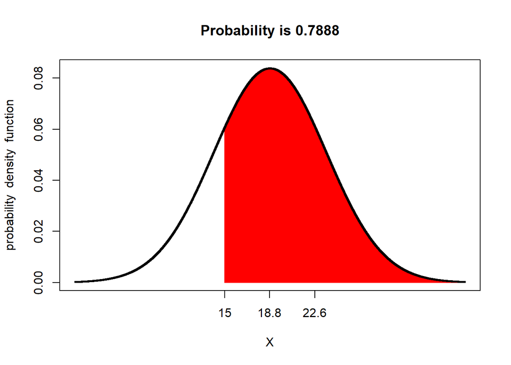

```r
shadeDist(15,"dnorm",18.818, 4.758352,F)
```

Determinar que tan probable es que un alumno de UTEC pague un monto menor o igual a 10 soles. P(Y<=10)

```r
pnorm(10, 18.818, 4.758352, lower.tail = TRUE)
```

```
## [1] 0.03192953
```

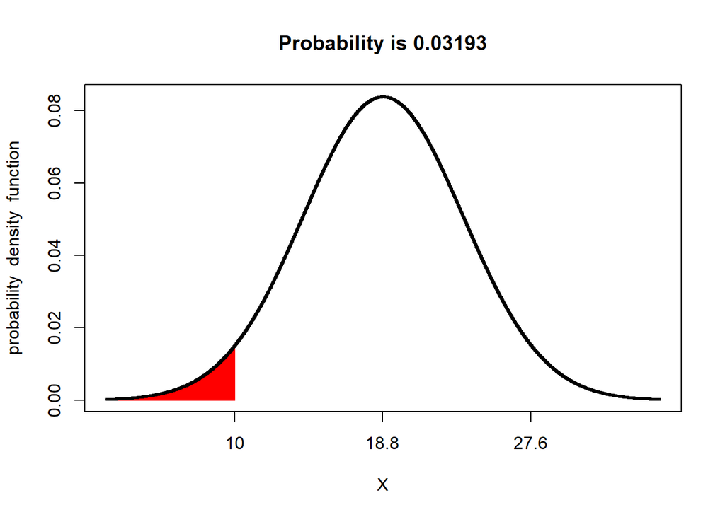

```r
shadeDist(10,"dnorm",18.818, 4.758352,T)
```

# 4 VARIABLES ALEATORIAS CONTINUAS 3era variable

## 4.1 GASTO DE TRANSPORTE

Análisis de tipo de distribución de la variable Gasto de transporte.

```r
GST <- BD2$GastoSemanalTransporte[BD2$GastoSemanalTransporte <=10]
fit.cont (GST)
```

```
##
## Begin fitting distributions ---------------------------------------
```

```
## * fitting normal distribution ... OK
```

```
## * fitting Cauchy  distribution ... OK
```

```
## * fitting logistic distribution ... OK
```

```
## * fitting beta distribution ... failed
```

```
## * fitting exponential distribution ... OK
```

```
## * fitting chi-square distribution ... failed
```

```
## * fitting uniform distribution ... OK
```

```
## * fitting gamma distribution ... failed
```

```
## * fitting lognormal distribution ... failed
```

```
## * fitting Weibull distribution ... failed
```

```
## * fitting F-distribution ... failed
```

```
## * fitting Student's t-distribution ... OK
```

```
## * fitting Gompertz distribution ... OK
```

```
## * fitting triangular distribution ... failed
```

```
## End fitting distributions -----------------------------------------
```

```
##                logL    AIC    BIC Chisq(value) Chisq(p) AD(value)    H(AD)
## Normal      -148.25  300.5 304.44        22.63     0.00      3.12 rejected
## Cauchy      -164.34 332.68 336.62        43.94     0.00      3.73 rejected
## Logistic    -151.16 306.32 310.26        21.92     0.00      2.82 rejected
## Exponential -129.91 261.82 263.79          Inf     0.00       Inf rejected
## Uniform        NULL   NULL   NULL        10.80     0.01      2.40     NULL
## Student     -177.86 357.73  359.7       225.15     0.00     23.66     NULL
## Gompertz    -129.62 263.24 267.18          Inf     0.00       Inf     NULL
##             KS(value)        H(KS)
## Normal           0.17 not rejected
## Cauchy           0.26     rejected
## Logistic         0.16 not rejected
## Exponential      0.30     rejected
## Uniform          0.19     rejected
## Student          0.50     rejected
## Gompertz         0.30     rejected
```

```
##
## Chosen continuous distribution is: NA
## Fitted parameters are:
## [1] NA
```

```r
mean(GST)
```

```
## [1] 4.267925
```

```r
var(GST)
```

```
## [1] 16.04636
```

```r
sd(GST)
```

```
## [1] 4.00579
```

```r
table(GST)
```

```
## GST
##    0    1  1.2 1.25  1.5  2.5    3    4    5    6 6.25    7    8    9   10
##   16    3    1    1    1    2    2    5    2    1    1    3    2    1   12
```

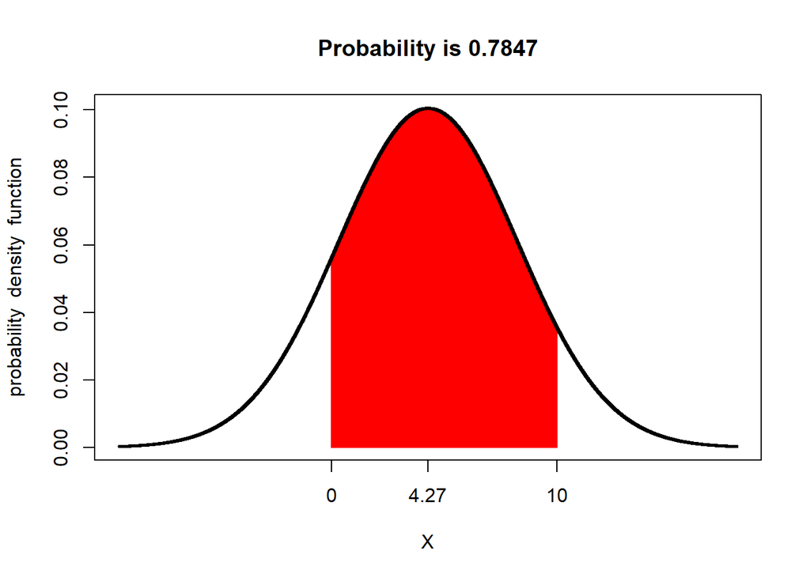

```r
shadeDist(xshade = c(0,10),"dnorm",4.267925, 3.967820,F)
```

Determinar que tan probable es que un alumno de UTEC pague como mínimo 20 soles. P(Y>=20)

```r
1-pnorm(20, 4.267925, 3.967820)
```

```
## [1] 3.671082e-05
```

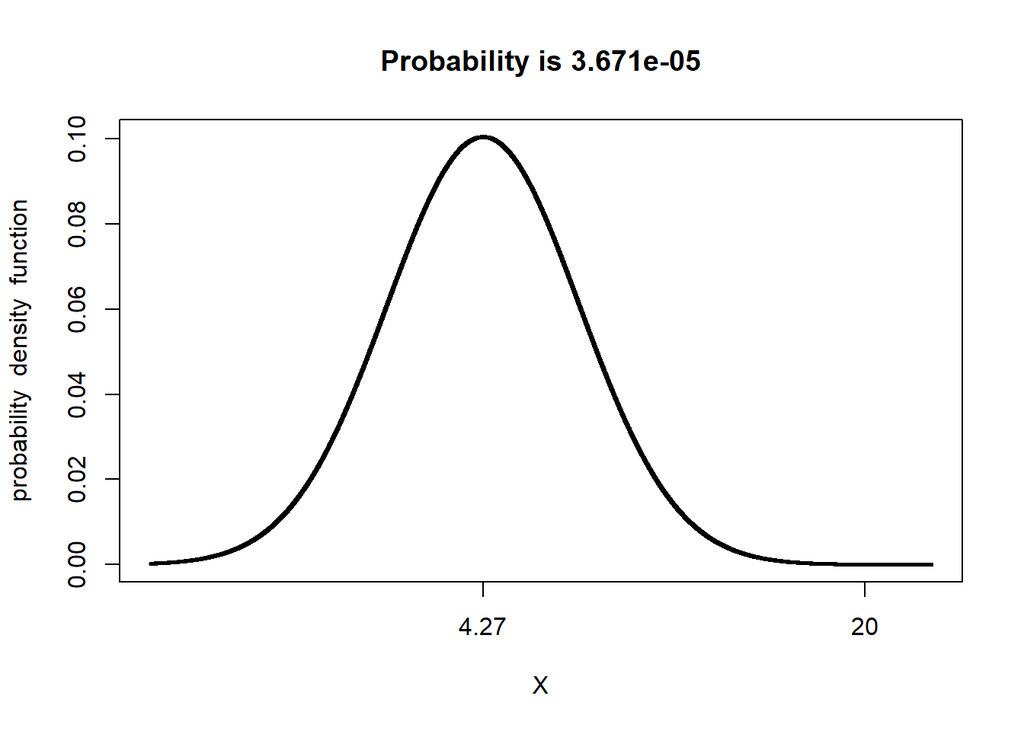

```r
shadeDist(xshade = 20,"dnorm",4.267925, 3.967820,F)
```

```r
fi = table( BD2$GastoSemanalTransporte[BD2$GastoSemanalTransporte >=20])
pi=round(prop.table(fi),4)
#pi
cbind(fi,pi)
```

```
##      fi     pi
## 20   14 0.1647
## 22    1 0.0118
## 23    1 0.0118
## 24    3 0.0353
## 25    7 0.0824
## 28    1 0.0118
## 30   13 0.1529
## 35    1 0.0118
## 36    1 0.0118
## 38.5  1 0.0118
## 40    9 0.1059
## 45    1 0.0118
## 50    8 0.0941
## 52.5  1 0.0118
## 55    1 0.0118
## 60    9 0.1059
## 65    1 0.0118
## 70    1 0.0118
## 75    1 0.0118
## 78    1 0.0118
## 80    1 0.0118
## 100   5 0.0588
## 120   1 0.0118
## 150   2 0.0235
```

# 5 Conclusiones

—Se ha observado que los estudiantes de la UTEC tienen una baja probabilidad de tener cinco gastos semanales, ya que se encontró que en promedio solo quince estudiantes tienen esos cinco gastos, mientras que la mayoría tiene menos de cinco gastos.

—Con respecto a la probabilidad condicional que si la ocurrencia o la no ocurrencia de uno de los eventos afecta de alguna forma la probabilidad del otro.

—Las variables aleatorias continuas tiene la capacidad para describir y analizar fenómenos complejos, en este caso nos permitió estimar la probabilidad de que un evento ocurra dentro de un rango específico. Se determinó la probabilidad del gasto mayor o igual a 15 soles que un alumno de UTEC puede gastar en un almuerzo siempre y cuando asista a la universidad. Se comprobó que existe una alta probabilidad que los estudiantes gasten más de 15 soles, sin embargo, esta probabilidad baja para aquellos que gasten un monto menor o igual a 10 soles.